# TP1_tendance_saisonnalite-sol

TP1 - Estimation de tendance et saisonnalité

```python
import matplotlib.pyplot as plt

import numpy as np

import pandas as pd

import statsmodels.api as sm
from statsmodels.graphics.tsaplots import plot_acf

from scipy.fft import fft, fftfreq
from scipy.stats import probplot, norm, linregress
```

```python
plt.rc("figure", figsize=(24, 8))
plt.rc("font", size=13)
```

Ce TP a pour but de mettre en pratique les méthodes d'analyse vues au Chapitre#1 du cours. On rappelle qu'on suppose la décomposition suivante pour une série temporelle observée $( x_t )_{t \in \mathbb{N}}$:

$$ x_t = m_t + s_t + \epsilon_t $$

Où $s_t$ est périodique et de somme nulle sur une période.

Nous chercherons à estimer $m_t$ et $s_t$ en "espérant" que ce qu'il reste dans $\hat{\epsilon_t} = x_t - \hat{m}_t - \hat{s}_t$ soit faiblement stationnaire, puisque les modèles de prévision classiques supposent très souvent la stationnarité faible des données (tout comme les processus Gaussiens).

### Import des données

```python
co2_data = sm.datasets.co2.load_pandas().data
```

```python
co2_data.head(5)
```

|  | co2 |
| --- | --- |
| 1958-03-29 | 316.1 |
| 1958-04-05 | 317.3 |
| 1958-04-12 | 317.6 |
| 1958-04-19 | 317.5 |
| 1958-04-26 | 316.4 |

```python
co2_data.describe()
```

|  | co2 |
| --- | --- |
| count | 2225.000000 |
| mean | 340.142247 |
| std | 17.003885 |
| min | 313.000000 |
| 25% | 324.800000 |
| 50% | 338.300000 |
| 75% | 354.800000 |
| max | 373.900000 |

La séries comporte plusieurs données manquantes. Nous allons les compléter par interpolation linéaire. Il existe des méthodes plus sophistiquées (techniques de 'missing data imputation' pour les intéressés) mais pour notre TP, ça suffira !

```python
# méthode du pd.DataFrame de pandas
co2_data.interpolate(method='time', inplace=True)
```

#### Visualisation / analyse qualitative

Visualisez la série temporelle à différentes échelles (par années, mois, etc).

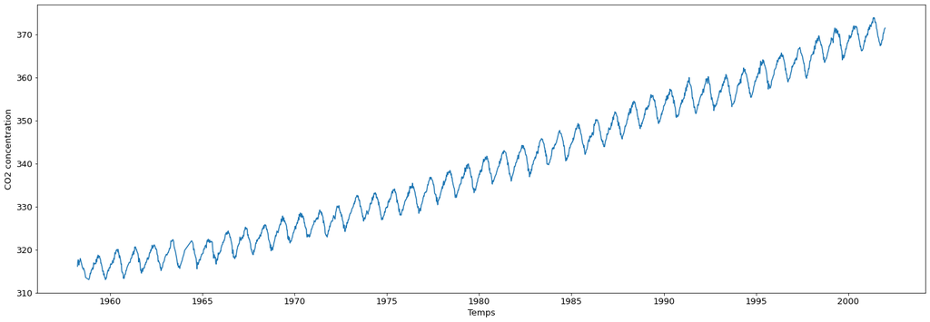

```python
plt.plot(co2_data['co2'])
plt.xlabel('Temps'); plt.ylabel('CO2 concentration')
```

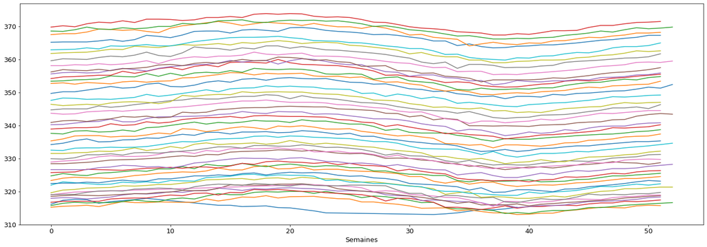

```python
# Visualisation au travers des années (une série par année)
years = co2_data.index.year
co2_data['year'] = co2_data.index.map(lambda t: t.year)

for year, data_year in co2_data.groupby('year'):

    # print(data_year['co2'].shape[0])
    plt.plot(np.arange(data_year.shape[0]), data_year['co2'])

plt.xlabel('Semaines')
```

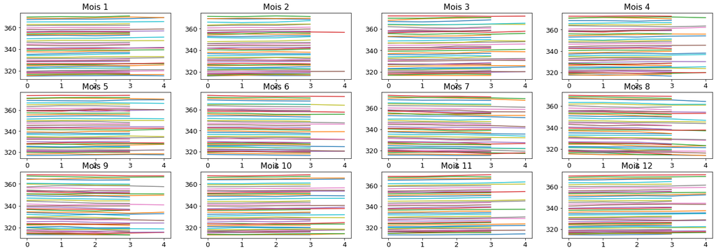

```python
# Visualisation au travers des mois
years = co2_data.index.year
co2_data['month'] = co2_data.index.map(lambda t: t.month)
co2_data['year_month'] = co2_data['year'] + co2_data['month']

for idx, (month, data_month) in enumerate(co2_data.groupby('month')):

    plt.subplot(3, 4, idx + 1)

    for year, data_month_year in data_month.groupby('year'):

        plt.plot(np.arange(data_month_year.shape[0]), data_month_year['co2'])
        plt.title(f'Mois {idx + 1}')
# plt.xlabel('Mois')
```

Qu'observez-vous qualitativement ? Le processus semble-t-il stationnaire ? Tendance ? Saisonnalité ?

### Estimation de la tendance et saisonnalité

Nous avons vu en cours que pour estimer la saisonnalité (resp. tendance), la série doit être corrigée de sa tendance (resp. saisonnalité).

Nous allons estimer la saisonnalité et la tendance de deux façons:

- Première façon: éliminer la tendance puis ajuster une composante saisonnale:
  - (1) estimation non-paramétrique de la tendance (par moyenne mobile à un ordre $r$ à déterminer !) $\hat{m}_t$, puis
  - (2) ajustement d'une composante saisonnale sur $x_t - \hat{m}_t$.
- Deuxième façon: éliminer la saisonnalité puis ajuster une composante de tendance
  - (1) différenciation de la série initiale (à un ordre $r$ à déterminer !)
  - (2) estimation de la tendance sur la série différenciée $\nabla_r x_t = m_t - m_{t - r} + \epsilon_t - \epsilon_{t - r}$

Rappels (voir formules pages 10-11 du poly):

- La moyenne mobile symmétrique, centrée et normalisée d'ordre $r=2q + 1$ estime la tendance et élimine la saisonnalité d'ordre $r$,
- L'opérateur de différenciation $\nabla_r X_t = X_t - X_{t - r}$ élimine la saisonnalité d'ordre $r$.

A. Estimez la tendance et la saisonnalité selon la première méthode. Discutez l'allule de cette tendance estimée.

```python
# Estimation non-paramétrique par moyenne mobile centrée, symmétrique, normalisée
## on a observé une saisonnalité annuelle
mm_co2 = co2_data['co2'].rolling(window='365D', center=True, closed='neither').mean()
```

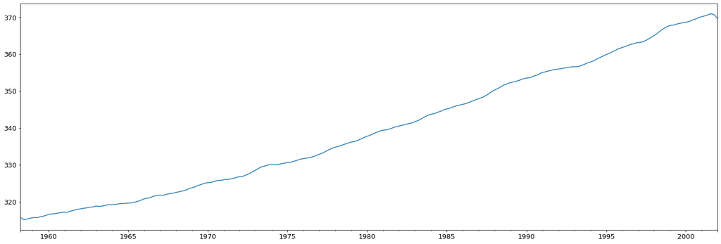

```python
mm_co2.plot()
```

```python
# Elimination de la tendance non-paramétrique estimée à la série initiale
s_co2 = co2_data['co2'] - mm_co2
s_co2 -= s_co2.mean() # centrage pour avoir une saisonnalité de moyenne temporelle nulle
```

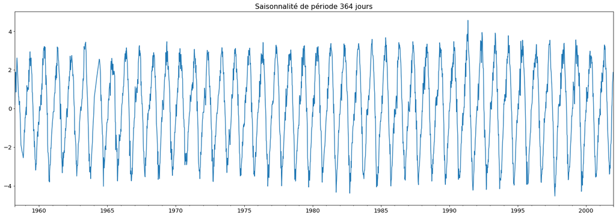

```python
s_co2.plot(title='Saisonnalité de période 364 jours')
```

Déterminez / vérifez la périodicité de la saisonnalité par transfomée de Fourier discrète. */* Indication, ne sélectionnez plusieurs fréquences importantes pour être robuste à l'alée de la périodicité.

```python
timestep = 1 # ici, un pas de temps = 7 jours = 1 semaine
freqs = fftfreq(s_co2.values.size, d=timestep) # renvoie des fréquences en unité hébdo (une semaine)
fourier_s_c02 = fft(s_co2.values)
```

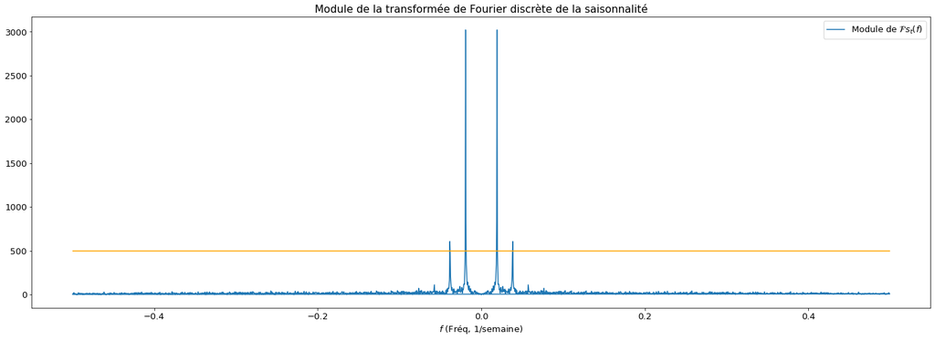

```python
plt.plot(freqs, np.abs(fourier_s_c02), label=r'Module de $\mathcal{F }s_t(f)$')
# plt.vlines(x=0.018, color='red', ymin=0, ymax=2500, label='Pics de fréquence')
# plt.vlines(x=0.03809107, color='red', ymin=0, ymax=2500)
plt.hlines(y=500, xmin=min(freqs), xmax=max(freqs), color='orange')

plt.xlabel(r'$f$ (Fréq, 1/semaine)')
plt.legend()
plt.title('Module de la transformée de Fourier discrète de la saisonnalité')
```

```python
# on séléctionne les fréquences pour lesquelles le module du spectre est >500
f_peak = freqs[np.where(np.abs(fourier_s_c02) >= 500)[0]]

# élimine les fréquences négatives (spectre symmétrique)
f_peak = np.unique(np.abs(f_peak))
```

```python
f_peak
```

```
array([0.01882662, 0.01926445, 0.01970228, 0.0385289 ])
```

En déduire une composante saisonnale à fréquence(s) adéquate(s).

Rappels: $$\cos(\frac{2 \pi}{\alpha} t) \text{ et } \sin(\frac{2 \pi}{\alpha} t) \text{ sont $\alpha$-périodiques }$$

$$\iff$$$$\cos(2 \pi f_0 t) \text{ et } \sin(2 \pi f_0 t) \text{ sont $\frac{1}{f_0}$-périodiques }$$

On peut alors proposer une composante saisonnale définie combinaison linéaire de sin/cos associés à ces deux fréquences:

$$ \hat{s}_t = \sum_{k=1}^{3} \hat{\alpha}_k \cos(\frac{2 \pi}{T_k} t) + \hat{\beta}_k \sin(\frac{2 \pi}{T_k} t)$$

Attention aux unités: $t$ doit être dans la même unité que $T_k$ !

L'estimation des $( \alpha_k, \beta_k )$, $k=1,2,3 \dots$ peut se faire par moindres carrés linéaires:

$$ ( \hat{\alpha}_1, \hat{\beta}_1, \hat{\alpha}_2, \hat{\beta}_2 ) = \arg\min_{\alpha_1, \beta_1, \alpha_2, \beta_2} \frac{1}{2} \sum_{i=1}^{n} ( s_i - \hat{s}_i)^2$$

```python
# facteur de conversion de nanoseconds vers semaine
k_ns_to_week = (10**9 * 60 * 60 * 24 * 7) # number of nanoseconds in a week

t = s_co2.index.map(lambda t: t.value / k_ns_to_week) # temps de nanoseconds à semaines
t -= t.min()

T1, T2, T3 = f_peak[-3:]**-1
#
s1 = np.sin(t * 2 * np.pi / T1) # t.value est en ns, il faut le passer en semaine
s2 = np.cos(t * 2 * np.pi / T1)
s3 = np.sin(t * 2 * np.pi / T2)
s4 = np.cos(t * 2 * np.pi / T2)
s5 = np.sin(t * 2 * np.pi / T3)
s6 = np.cos(t * 2 * np.pi / T3)

# lstqs minimise Ax = b:
# Ici: A = [sin(2*pi*t/T1), cos(2*pi*t/T1), ...] et b = [s_1, ... s_n]
X = np.c_[s1, s2, s3, s4, s5, s6]
coefs = np.linalg.lstsq(X, s_co2.values, rcond=1e-10)[0]
```

```python
coefs
```

```
array([ 2.44059429,  1.01723391,  0.34561667,  0.2773327 , -0.46116472,
       -0.26078498])
```

```python
# composante de saisonnalité estimée
s_hat = np.dot(X, coefs)
```

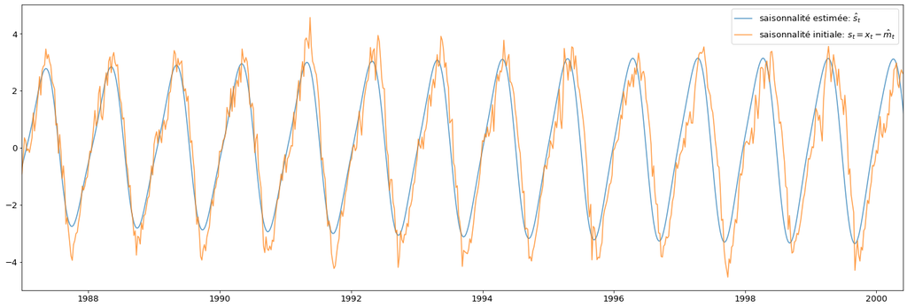

```python
# t = s_co2.index.map(lambda t: t.value / k_ns_to_week) # temps de nanoseconds à semaines

# plt.plot(s_co2.index, s_hat(t, coefs[[0, 1, 2, 3, 4, 5]], T = [T1, T2, T3]), label=r'saisonnalité estimée: $\hat{s}_t$', alpha=0.75)
plt.plot(s_co2.index, s_hat, label=r'saisonnalité estimée: $\hat{s}_t$', alpha=0.75)
plt.plot(s_co2.index, s_co2.values, label=r'saisonnalité initiale: $s_t = x_t - \hat{m}_t$', alpha=0.75) #

plt.xlim(s_co2.index[1500], s_co2.index[2200])
plt.legend()
```

Analysez la qualité de l'estimation $( \hat{s}_t)$, qualitativement (et quantitativement pour les puristes).

Qualitativement: notre ajustement semble sous-estimer la saisonnalité observée.

Quantitativement: regardons le QQ-plot, c-à-d le graphe des quantiles des résidus $s_t - \hat{s}_t$ versus les quantiles de la loi normale $\mathcal{N}(\mu=0, \sigma^2)$ . Si les résidus suivent cette densité de proba, ce graphe doit être une droite $y = ax+b$ avec $a \approx 1$ et $b \approx 0$.

Rappel: les résidus d'un ajustement linéaire sont asymptotiquement gaussiens.

```python
res_s = s_co2.values - s_hat

# écart-type de la gaussienne des résidus
np.std(res_s, ddof=4) # ddof est la variable de division dans (N - ddof)
```

```
0.8386813759359
```

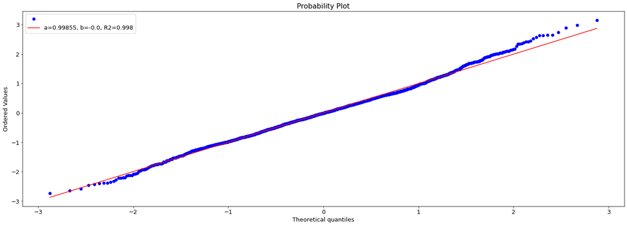

```python
# scipy.stats.probplot
res_qq = probplot(res_s, dist=norm(loc=0.0, scale=np.std(res_s, ddof=4)), plot=plt)[1]
plt.legend([None, f'a={round(res_qq[0], 5)}, b={round(res_qq[1], 5)}, R2={round(res_qq[2], 3)}'])
```

$a$ est très proche de 1 et $b$ est quasi nul. $b$ s'interprète comme une différence (biais) entre la centralité (ici moyenne) des résidus et la centralité de la distribution théorique des résidus, $\mathcal{N}(\mu=0, \sigma^2)$. A contrario, $a$ représente le ratio des dispersions entre ces distributions.

Nous concluons que notre modèle de saisonnalité $\hat{s}_t$ sur-estime ou sous-estime la saisonnalité (en particulier les fortes amplitudes).

On a donc un modèle $\hat{x}_t = \hat{m}_t + \hat{s}_t + \hat{\epsilon}_t$, où $(\hat{\epsilon}_t)_{t}$ est induit par $(\hat{m}_t, \hat{s}_t)_{t}$. Cependant, $(\hat{m}_t)_t$ a été estimé de façon non-paramétrique (modèle non-explicite à partir de $t$), ce qui nous empêche l'accès à $x_t$ pour $t > T_{observé} = 29/12/2001$. Si nous ne comprenez pas pourquoi, posez-vous la question: "Quelle la valeur de $\hat{m}_t$ pour $t > T_{observé}$ ?".

Réponse: on ne sait pas ! Rappelons que $(\hat{m}_t)_t$ a été estimé par moyenne mobile symmétrique. En conséquence, $\hat{m}_t$ dépend de $x_{t-q-1}, ..., x_t, ... x_{t+q+1}$ et donc ... du futur, ce qui reste utile pour l'analyse exploratoire mais inexploitable pour l'étape de prédiction !

Rien ne nous empêche d'éliminer la saisonnalité estimée $(\hat{s}_t)_{t}$ à la série initiale et de réestimer une tendance, cette fois-ci paramétrique, sur $( x_t - \hat{s}_t)$.

Proposez un modèle paramétrique simple pour représenter la tendance.

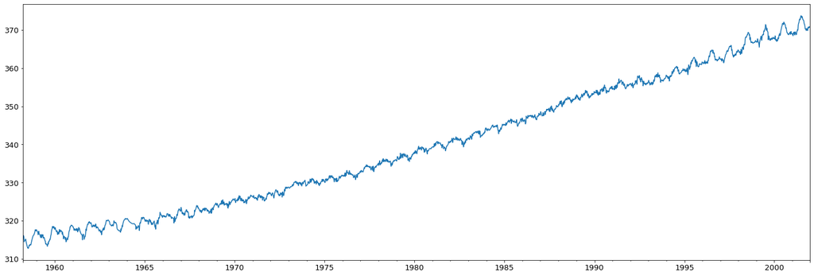

```python
# série initiale corrigée de la saisonnalité estimée
x_wt_s_co2 = co2_data['co2'] - s_hat
x_wt_s_co2.plot()
```

On observe une tendance monotonne avec des "restes" de saisonnalité (les grandes amplitudes de $\hat{s}_t$ sous-estimées). Un polynôme en $t$ à bas degré, $\hat{m}_t = \hat{a} t + \hat{b}$ pour commencer, ferait un bon candidat.

```python
# régression linéaire des valeurs corrigées de la saisonnalité estimatée par rapport à t
# t = s_co2.index.map(lambda t: t.value / k_ns_to_week) # temps de nanoseconds à semaines
coefs = linregress(x=t, y=x_wt_s_co2.values)[:2]
a_hat, b_hat = coefs
m_lin = (a_hat * t + b_hat)
```

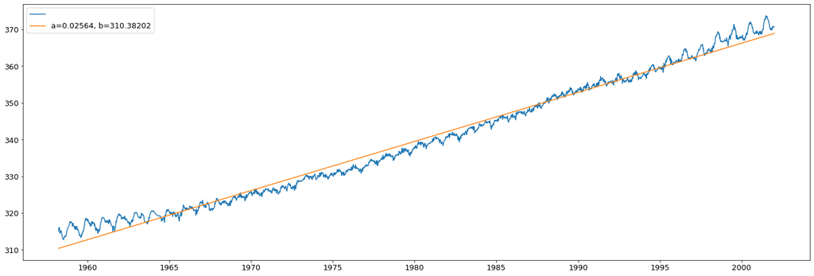

```python
plt.plot(x_wt_s_co2.index, x_wt_s_co2)
plt.plot(x_wt_s_co2.index, m_lin)
plt.legend([None, f'a={round(a_hat, 5)}, b={round(b_hat, 5)}'])
```

Discutez et analysez qualitativement votre ajustement.

Et un polynôme quadratique ?

```python
coefs = np.polyfit(t, x_wt_s_co2.values, deg=2)
m_quad = np.poly1d(coefs)(t)
```

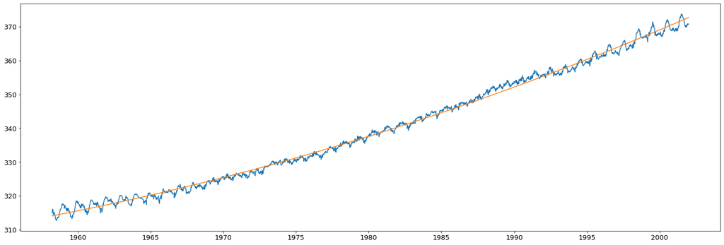

```python
plt.plot(x_wt_s_co2.index, x_wt_s_co2)
plt.plot(x_wt_s_co2.index, m_quad)
```

L'ajustement quadratique semble, qualitativement, meilleur que l'ajustement linéaire. On retiendra l'ajustement quadratique.

Examinez la série initiale corrigée à la fois de la saisonnalité estimée et de la (nouvelle) tendance estimée. Que dire de cette série ? Discutez sa stationnarité.

```python
x_wt_m_s_co2 = co2_data['co2'] - s_hat - m_quad
x_wt_m_s_co2 -= x_wt_m_s_co2.mean()
```

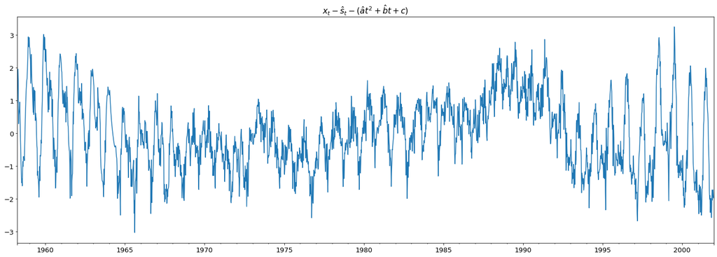

```python
x_wt_m_s_co2.plot(title=r'$x_t - \hat{s}_t - (\hat{a} t^2 + \hat{b} t + c)$')
```

La série n'est certainement pas fortement stationnaire puisqu'elle présente une variance grande jusqu'en 1965 et plus petite au-delà. Aussi la variance re-croît à partir de 1995.

Stationnarité faible: la série semble nulle en moyenne. L'auto-covariance semble indépendante du temps. Une analyse plus poussée sur ces dernières propriétés serait la bienvenue. Gardons à l'esprit que tout cela est conditionné par nos estimations de tendance et de saisonnalité, qui ont leurs imperfections.

B. Estimez la tendance et la saisonnalité selon la deuxième méthode.

Différenciez la série initiale à un (ou plusieurs) ordre(s). Que dire de la série obtenue ?

```python
# différenciation à l'ordre 52 (une année) de la série initiale
x_diff_52 = co2_data['co2'].rolling(window='365D').apply(lambda w: w[-1] - w[0])
x_diff_52_26 = x_diff_52.rolling(window='182D').apply(lambda w: w[-1] - w[0])
```

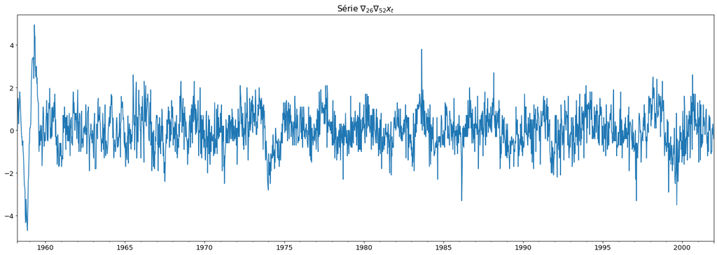

```python
x_diff_52_26.plot(title=r'Série $\nabla_{26} \nabla_{52} x_t$')
```

La série différenciée à l'ordre 52 puis différenciée à l'ordre 26 (periodicités trouvées précedemment) semble de moyenne nulle. Sa variance semble constante. Il est difficile d'en dire plus sur l'auto-corrélation.

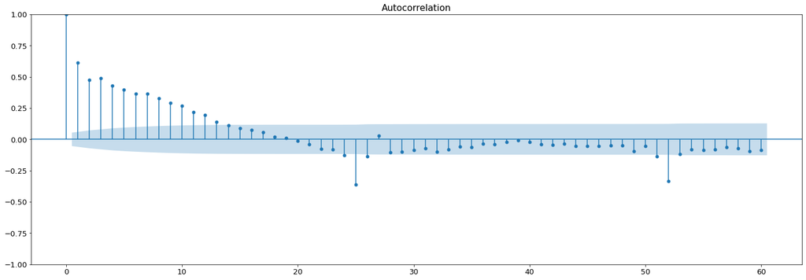

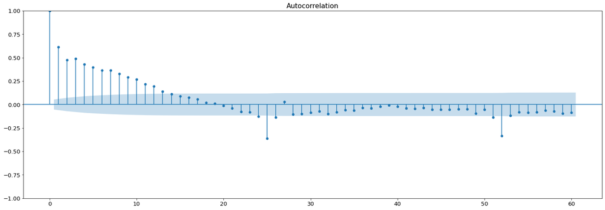

```python
# auto-corrélation de la série différenciée
plot_acf(x_diff_52_26, missing='drop', lags=60, fft=True, alpha=0.01)
```

L'auto-corrélation présente une décroissance jusqu'à 13 semaines, puis est nulle presque partout sauf à 25 et 52 semaines. La décroissance à court terme témoigne de la présence d'une tendance dans la série différenciée. Les différenciations aux ordres 52 et 26 n'ont pas complètement éliminé la saisonnalité. Nuancons, ces corrélations (négatives) sont relativement faibles en valeur absolue, $<0.5$. Ceci peut être dû à la dispersion de la pérdiodicité, bien qu'ici son modèle est déterministe.

La série différenciée pourrait être faiblement stationnaire.

Estimez la tendance de la série différenciée par deux méthodes de votre choix et discutez leurs différences en faisant jouer leur paramètre.

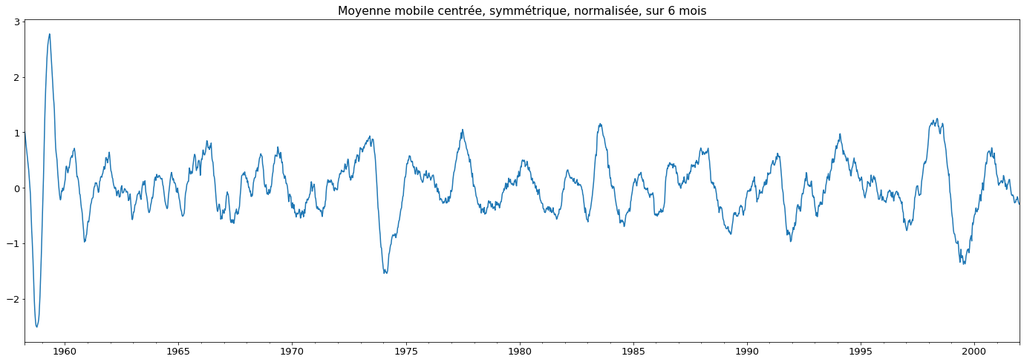

```python
# Estimation de tendance sur la série différenciée par moyenne mobile à 'petite' fenêtre
x_diff_52_26.rolling(window='181D', center=True, closed='neither').mean().plot(title='Moyenne mobile centrée, symmétrique, normalisée, sur 6 mois')
```

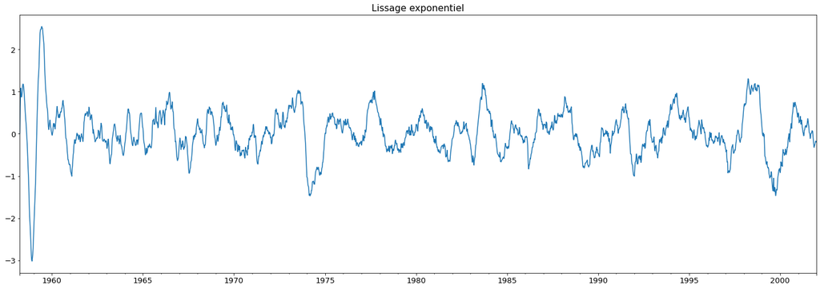

```python
# Tendance par lissage exponentiel
m_ewm = x_diff_52_26.ewm(alpha=1e-1).mean()
m_ewm.plot(title='Lissage exponentiel')
```